**Stochastic and Mini-batch Gradient Descent**

By Prof. Seungchul Lee  
http://iai.postech.ac.kr/  
Industrial AI Lab at POSTECH

Table of Contents

# 1. Gradient Descent Algorithm

Optimization refers to the task of minimizing (or maximizing) an objective function $f(x)$ parameterized by $x$. In machine learning or deep learning, it is the task of minimizing the loss function $L(\omega)$ parameterized by the model's parameters $\omega \in \mathbb{R}^n$. Optimization algorithms have following goals:

- Find global minimum of the objective function. (If the objective function is convex, any local mimimum is a global minimum)

Gradient descent is the most common optimization algorithm in machine learning and deep learning. It is a first-order optimization algorithm. This means it only takes into account the first derivative when performing the updates on the parameters. On each iteration, we updates on the parameters in the opposite direction of the gradient of the objective function $L(\omega)$ w.r.t the parameters where the gradient gives direction of the steepest descent. The size of the step we take on eack iteration is determined by the learning rate $\alpha$. Thus, we follow the direction of the slope downhill until we reach a local minimum.

- It motivates the gradient descent algorithm, which repeatedly takes steps in the direction of the negative gradient

$$ x \leftarrow x - \alpha \nabla _x f(x) \quad \quad \text{for some step size } \alpha > 0$$

[figure not shown]

- Gradient Descent

$$\text{Repeat : } x \leftarrow x - \alpha \nabla _x f(x) \quad \quad \text{for some step size } \alpha > 0$$

[figure not shown]

- Gradient Descent in Higher Dimension

$$\text{Repeat : } x \leftarrow x - \alpha \nabla _x f(x)$$

[figure not shown]

In this lecture, we will cover gradient descent algorithm and its variants:

- Batch Gradient Descent
- Stochastic Gradient Descent
- Mini-batch Gradient Descent

We will explore the concept of these three gradient descent algorithms with a logistic regression model.

# 2. Batch Gradient Descent

(= Gradient Descent)

In Batch Gradient Descent methods, we use all of the training data set for each iteration. So, for each update, we have to sum over all examples.

The main advantages:

- We can use fixed learning rate during training without worring about learining rate decay.
- It has straight trajectory towards the minimum
- It guaranteed to converge in theory to the global minimum if the loss function is convex and to a local minimum if the loss function is not convex.
- It has unbiased estimate of gradients. As increasing the number of examples, standard error will decreasing.

Even if it is safe and accurate method, it is very inefficient in terms of computation.

The main disadvantages:

- When we have large data set, this method may slow to converge.
- Each step of learning happens after going over all examples where some examples may be redundant and don’t contribute much to the update.

```python
import numpy as np
import matplotlib.pyplot as plt
import tensorflow as tf
import time
%matplotlib inline
```

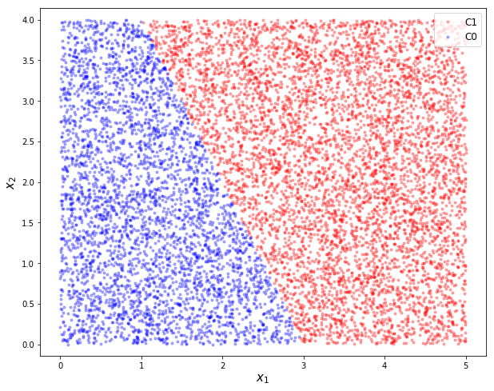

```python
# datat generation

m = 10000
true_w = np.array([[-6], [2], [1]])
train_X = np.hstack([np.ones([m,1]), 5*np.random.rand(m,1), 4*np.random.rand(m,1)])

true_w = np.asmatrix(true_w)
train_X = np.asmatrix(train_X)

train_y = 1/(1 + np.exp(-train_X*true_w)) > 0.5

C1 = np.where(train_y == True)[0]
C0 = np.where(train_y == False)[0]

train_y = np.empty([m,1])
train_y[C1] = 1
train_y[C0] = 0

plt.figure(figsize = (10,8))
plt.plot(train_X[C1,1], train_X[C1,2], 'r.', alpha = 0.3, label = 'C1')
plt.plot(train_X[C0,1], train_X[C0,2], 'b.', alpha = 0.3, label = 'C0')
plt.xlabel(r'$x_1$', fontsize = 15)
plt.ylabel(r'$x_2$', fontsize = 15)
plt.legend(loc = 1, fontsize = 12)
plt.axis('equal')
# plt.xlim([0,4])
plt.ylim([0,4])
plt.show()
```

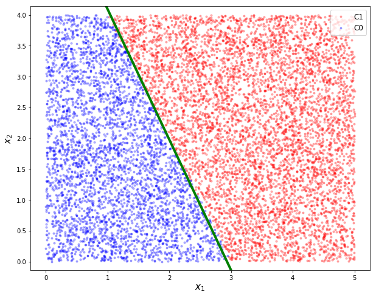

```python
LR = 0.04
n_iter = 60000
n_prt = 250

x = tf.placeholder(tf.float32, [m, 3])
y = tf.placeholder(tf.float32, [m, 1])

w = tf.Variable([[0],[0],[0]], dtype = tf.float32)

y_pred = tf.matmul(x,w)
loss = tf.nn.sigmoid_cross_entropy_with_logits(logits=y_pred, labels=y)
loss = tf.reduce_mean(loss)

optm = tf.train.GradientDescentOptimizer(LR).minimize(loss)
init = tf.global_variables_initializer()

start_time = time.time()

loss_record = []
with tf.Session() as sess:
    sess.run(init)
    for epoch in range(n_iter):
        sess.run(optm, feed_dict = {x: train_X, y: train_y})

        if (epoch + 1) % n_prt == 0:
            loss_record.append(sess.run(loss, feed_dict = {x: train_X, y: train_y}))

    w_hat = sess.run(w)

training_time = time.time() - start_time

xp = np.arange(0, 4, 0.01).reshape(-1, 1)
yp = - w_hat[1,0]/w_hat[2,0]*xp - w_hat[0,0]/w_hat[2,0]

plt.figure(figsize=(10,8))
plt.plot(train_X[C1,1], train_X[C1,2], 'r.', alpha = 0.3, label='C1')
plt.plot(train_X[C0,1], train_X[C0,2], 'b.', alpha = 0.3, label='C0')
plt.plot(xp, yp, 'g', linewidth = 4)
plt.xlabel(r'$x_1$', fontsize = 15)
plt.ylabel(r'$x_2$', fontsize = 15)
plt.legend(loc = 1, fontsize = 12)
plt.axis('equal')
# plt.xlim([0,4])
plt.ylim([0,4])
plt.show()
```

We will check two pieces of information

- time spend for training session, and
- loss function noise.

```
21.65193510055542
```

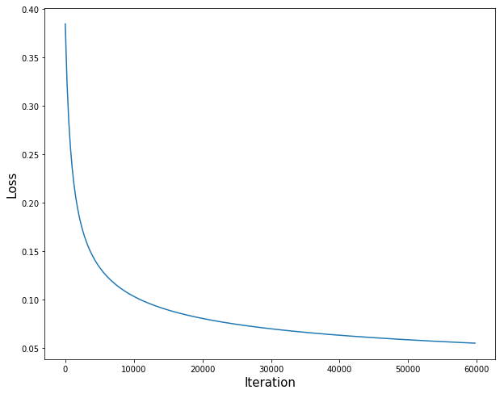

```python
print(training_time)

plt.figure(figsize=(10,8))
plt.plot(range(1, n_iter+1, n_prt), loss_record)
plt.xlabel('Iteration', fontsize = 15)
plt.ylabel('Loss', fontsize = 15)
plt.show()
```

# 3. Stochastic Gradient Descent (SGD)

Stochastic Gradient Descent is an extreme case of Mini-batch Gradient Descent. In this case, learning happens on every example. This is less common than the mini-batch gradient descent method.

The advantages:

- It adds even more noise to the learning process than mini-batch that helps improving generalization error.

The disadvantages:

- It use only one example for each update. But one example hardly can represent whole data set. In other words, the variance becomes large since we only use one example for each learning step.
- Due to the noise, the learning steps have more oscillations.
- It become very slow since we can't utilize vectorization over only one example.

Below is a graph that shows the gradient descent's variants and their direction towards the minimum:

[figure not shown]

As we can see in figure, SGD direction is very noisy compared to others.

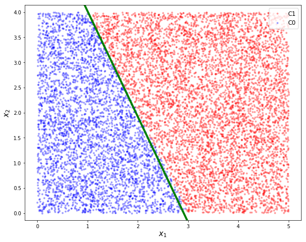

```python
LR = 0.04
n_iter = 60000
n_prt = 250

x = tf.placeholder(tf.float32, [1, 3])
y = tf.placeholder(tf.float32, [1, 1])

w = tf.Variable(tf.random_normal([3,1]), dtype = tf.float32)

y_pred = tf.matmul(x,w)
loss = tf.nn.sigmoid_cross_entropy_with_logits(logits=y_pred, labels=y)
loss = tf.reduce_mean(loss)

optm = tf.train.GradientDescentOptimizer(LR).minimize(loss)
init = tf.global_variables_initializer()

start_time = time.time()

loss_record = []
with tf.Session() as sess:
    sess.run(init)
    for epoch in range(n_iter):
        idx = np.random.choice(m, 1)
        batch_X = train_X[idx,:]
        batch_y = train_y[idx]
        sess.run(optm, feed_dict = {x: batch_X, y: batch_y})

        if (epoch + 1) % n_prt == 0:
            loss_record.append(sess.run(loss, feed_dict = {x: batch_X, y: batch_y}))

    w_hat = sess.run(w)

training_time = time.time() - start_time

xp = np.arange(0, 4, 0.01).reshape(-1, 1)
yp = - w_hat[1,0]/w_hat[2,0]*xp - w_hat[0,0]/w_hat[2,0]

plt.figure(figsize=(10,8))
plt.plot(train_X[C1,1], train_X[C1,2], 'r.', alpha = 0.3, label='C1')
plt.plot(train_X[C0,1], train_X[C0,2], 'b.', alpha = 0.3, label='C0')
plt.plot(xp, yp, 'g', linewidth = 4)
plt.xlabel(r'$x_1$', fontsize = 15)
plt.ylabel(r'$x_2$', fontsize = 15)
plt.legend(loc = 1, fontsize = 12)
plt.axis('equal')
# plt.xlim([0,4])
plt.ylim([0,4])
plt.show()
```

```
17.074392557144165
```

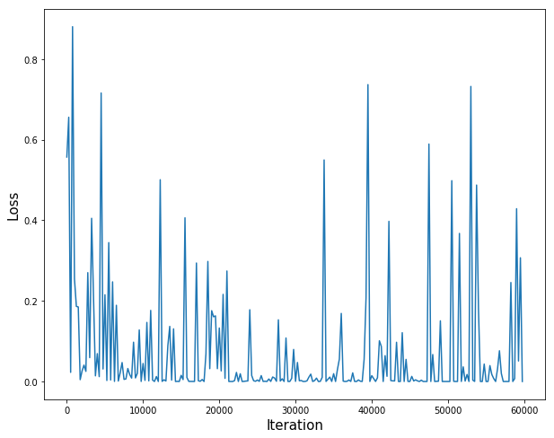

```python
print(training_time)

plt.figure(figsize=(10,8))
plt.plot(range(1, n_iter+1, n_prt), loss_record)
plt.xlabel('Iteration', fontsize = 15)
plt.ylabel('Loss', fontsize = 15)
plt.show()
```

# 4. Mini-batch Gradient Descent

Mini-batch Gradient Descent method is often used in machine learning and deep learning training. The main idea is similar with batch gradient descent. However, unlike batch gradient descent, in this method, we can customize the batch size. Instead of going over all examples, mini-batch gradient descent sums up over lower number of examples based on the batch size. So, parameters are updated based on mini-batch for each iteration. Since we assume the examples in the data set has positive correlation, this method can be used. In other words, in large data set, there are lots of similar examples.

The main advantages:

- Faster than batch gradient descent. Since it goas through a lot less examples than batch gradient descent(all examples).
- Since we randomly choose the mini-batch examples, we can avoid redundant examples and examples that are very similar that don't contribute much to the learning.
- With batch size $<$ size of training set, it can adds noise to the learning process that helps improving generaization error.

The main disadvantages:

- It won't converge. On each iteration, the learning step mat go back and forth due to the noise. So, it wanders around the minimum region but never converges.
- Due to the noise, the learning steps have more oscillations.

[figure not shown]

Note that if batch size is equal to number of training examples, mini-batch gradient descent method is same with batch gradient descent.

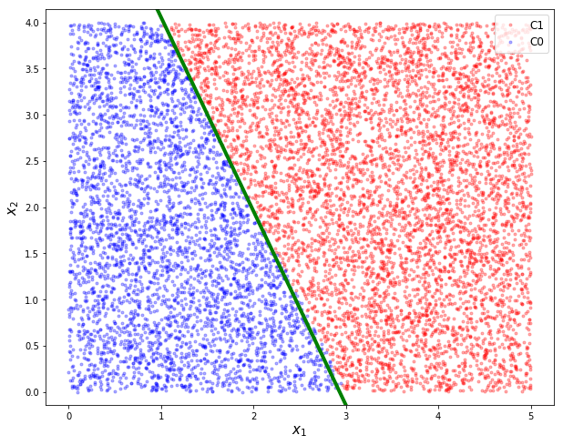

```python
LR = 0.04
n_iter = 60000
n_batch = 50
n_prt = 250

x = tf.placeholder(tf.float32, [n_batch, 3])
y = tf.placeholder(tf.float32, [n_batch, 1])

w = tf.Variable(tf.random_normal([3,1]), dtype = tf.float32)

y_pred = tf.matmul(x,w)
loss = tf.nn.sigmoid_cross_entropy_with_logits(logits=y_pred, labels=y)
loss = tf.reduce_mean(loss)

optm = tf.train.GradientDescentOptimizer(LR).minimize(loss)
init = tf.global_variables_initializer()

start_time = time.time()

loss_record = []
with tf.Session() as sess:
    sess.run(init)
    for epoch in range(n_iter):
        idx = np.random.choice(m, size = n_batch)
        batch_X = train_X[idx,:]
        batch_y = train_y[idx]
        sess.run(optm, feed_dict = {x: batch_X, y: batch_y})

        if (epoch + 1) % n_prt == 0:
            loss_record.append(sess.run(loss, feed_dict = {x: batch_X, y: batch_y}))

    w_hat = sess.run(w)

training_time = time.time() - start_time

xp = np.arange(0, 4, 0.01).reshape(-1, 1)
yp = - w_hat[1,0]/w_hat[2,0]*xp - w_hat[0,0]/w_hat[2,0]

plt.figure(figsize=(10,8))
plt.plot(train_X[C1,1], train_X[C1,2], 'r.', alpha = 0.3, label='C1')
plt.plot(train_X[C0,1], train_X[C0,2], 'b.', alpha = 0.3, label='C0')
plt.plot(xp, yp, 'g', linewidth = 4)
plt.xlabel(r'$x_1$', fontsize = 15)
plt.ylabel(r'$x_2$', fontsize = 15)
plt.legend(loc = 1, fontsize = 12)
plt.axis('equal')
# plt.xlim([0,4])
plt.ylim([0,4])
plt.show()
```

```
17.286964654922485
```

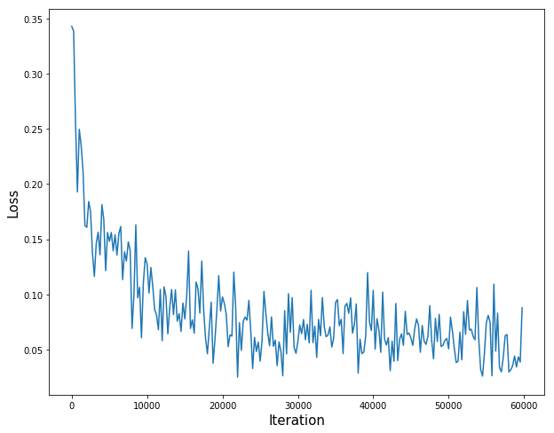

```python
print(training_time)

plt.figure(figsize=(10,8))
plt.plot(range(1, n_iter+1, n_prt), loss_record)
plt.xlabel('Iteration', fontsize = 15)
plt.ylabel('Loss', fontsize = 15)
plt.show()
```

```python
%%javascript
$.getScript('https://kmahelona.github.io/ipython_notebook_goodies/ipython_notebook_toc.js')
```